# Homework 4

Drew Wilimitis

November 7, 2017

## 1.) Modified from Exercises 5.4

### Perform a thorough analysis of the Education Expenditures data in Tables 5.12, 5.13, and 5.14. You are expected to examine the relationship between Y and X1, X2, X3 and Region over time.

```r
rawData <- read.delim("http://statistics.uchicago.edu/~collins/data/RABE5/P151-153.txt")
head(rawData)
```

```
##   state  y   x1  x2  x3 region year
## 1    ME 61 1704 388 399      1 1960
## 2    NH 68 1885 372 598      1 1960
## 3    VT 72 1745 397 370      1 1960
## 4    MA 72 2394 358 868      1 1960
## 5    RI 62 1966 357 899      1 1960
## 6    CT 91 2817 362 690      1 1960
```

#### a.) Create appropriate indicator variables for the region variable.

We use the “dummies” package in R to create indicator variables Region1, Region2, Region3, and Region4.

```r
rawDummy <- dummy.data.frame(rawData, names=c("region"))
rawDummy <- mutate(rawDummy, region = rawData$region)
kable(head(rawDummy, 10))
```

| state | y | x1 | x2 | x3 | region1 | region2 | region3 | region4 | year | region |
| --- | --- | --- | --- | --- | --- | --- | --- | --- | --- | --- |
| ME | 61 | 1704 | 388 | 399 | 1 | 0 | 0 | 0 | 1960 | 1 |
| NH | 68 | 1885 | 372 | 598 | 1 | 0 | 0 | 0 | 1960 | 1 |
| VT | 72 | 1745 | 397 | 370 | 1 | 0 | 0 | 0 | 1960 | 1 |
| MA | 72 | 2394 | 358 | 868 | 1 | 0 | 0 | 0 | 1960 | 1 |
| RI | 62 | 1966 | 357 | 899 | 1 | 0 | 0 | 0 | 1960 | 1 |
| CT | 91 | 2817 | 362 | 690 | 1 | 0 | 0 | 0 | 1960 | 1 |
| NY | 104 | 2685 | 341 | 728 | 1 | 0 | 0 | 0 | 1960 | 1 |
| NJ | 99 | 2521 | 353 | 826 | 1 | 0 | 0 | 0 | 1960 | 1 |
| PA | 70 | 2127 | 352 | 656 | 1 | 0 | 0 | 0 | 1960 | 1 |
| OH | 82 | 2184 | 387 | 674 | 0 | 1 | 0 | 0 | 1960 | 2 |

#### b.) Treat the year variable as ordinal, not nominal. More specifically, recode the variable as 0 (1960), 10 (1970), and 15 (1975). Note: This is different from the textbook suggestion of 0/1 indicator variables in Section 5.7.

Using dplyr, we recode the year variable as ordinal.

```r
rawDummy <- rawDummy %>%
  mutate(year = ifelse(year == 1960, 0,
                       ifelse(year == 1970, 10,
                              ifelse(year == 1975, 15, year))))
```

#### c.) Fit a model to the data. In your model, include X1, X2, X3, year, region indicator variables, and interaction effects to allow the coefficients (“slopes”) for X1, X2, X3 to vary by year.

```r
raw_interact <- lm(y ~ x1 + x2 + x3 + region2 + region3 + region4 + year + year*x1 + year*x2 + year*x3, data = rawDummy)
tidy(raw_interact)
```

```
##           term      estimate    std.error  statistic      p.value
## 1  (Intercept)  1.570217e+01 4.900127e+01  0.3204442 7.491129e-01
## 2           x1  4.833205e-02 1.130362e-02  4.2758021 3.518101e-05
## 3           x2  1.615593e-02 8.557745e-02  0.1887872 8.505350e-01
## 4           x3 -5.986911e-02 3.236795e-02 -1.8496418 6.648894e-02
## 5      region2 -1.288079e+00 7.393066e+00 -0.1742280 8.619398e-01
## 6      region3 -3.738083e+00 7.866489e+00 -0.4751908 6.353968e-01
## 7      region4  2.322008e+01 7.804429e+00  2.9752434 3.453374e-03
## 8         year -2.696902e+01 6.039216e+00 -4.4656499 1.638675e-05
## 9      x1:year  1.471780e-03 7.099605e-04  2.0730456 4.001464e-02
## 10     x2:year  7.538039e-02 1.334322e-02  5.6493386 8.766455e-08
## 11     x3:year  6.641502e-04 2.880599e-03  0.2305598 8.179958e-01
```

#### d.) Plot the studentized (standardized) residuals vs. the fitted values (yb). Draw a normal probability plot (quantile plot) of the studentized (standardized) residuals. Which model assumptions appear to be violated? Explain.

First we plot the standardized residuals vs. the fitted values:

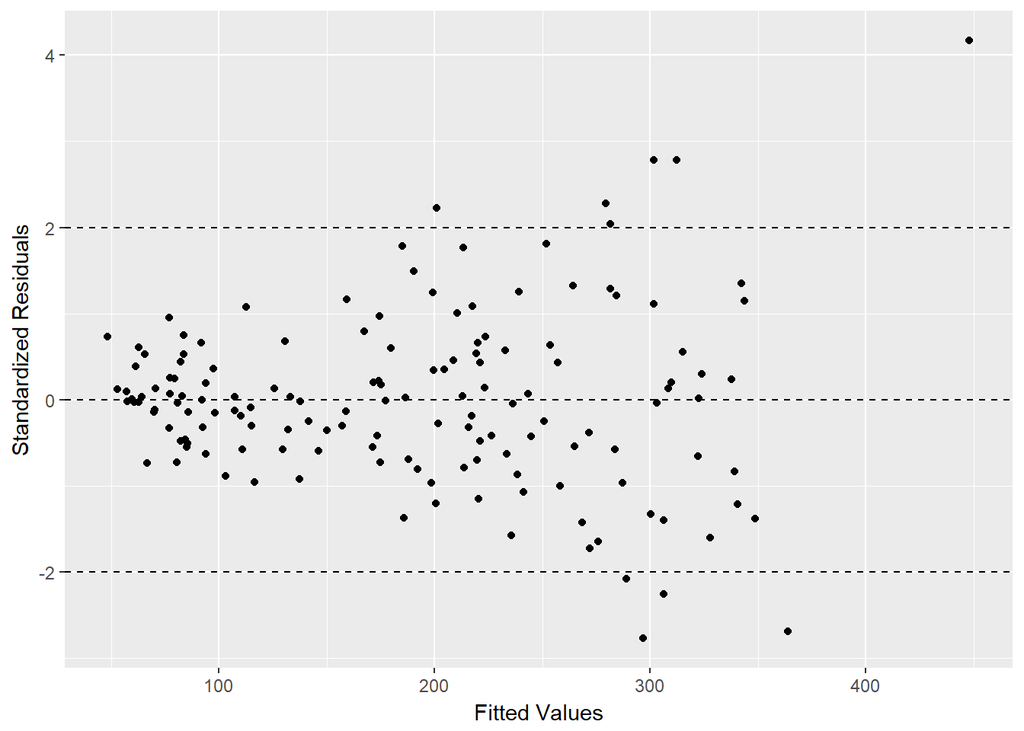

```r
rawDummy <- rawDummy %>%
  mutate(std_res = rstandard(raw_interact), fitted_values = fitted(raw_interact))

gf_point(std_res ~ fitted_values, data=rawDummy) %>%
  gf_labs(x = "Fitted Values", y = "Standardized Residuals") %>%
  gf_hline(yintercept = c(-2,0,2), linetype=2)
```

It seems that the model assumption of constant variance for the errors is violated here. The spread of standardized residuals seemes to get much larger as the fitted values increase, which shows that the variance is non-constant.

Next we make the normal probability plot of the standardized residuals:

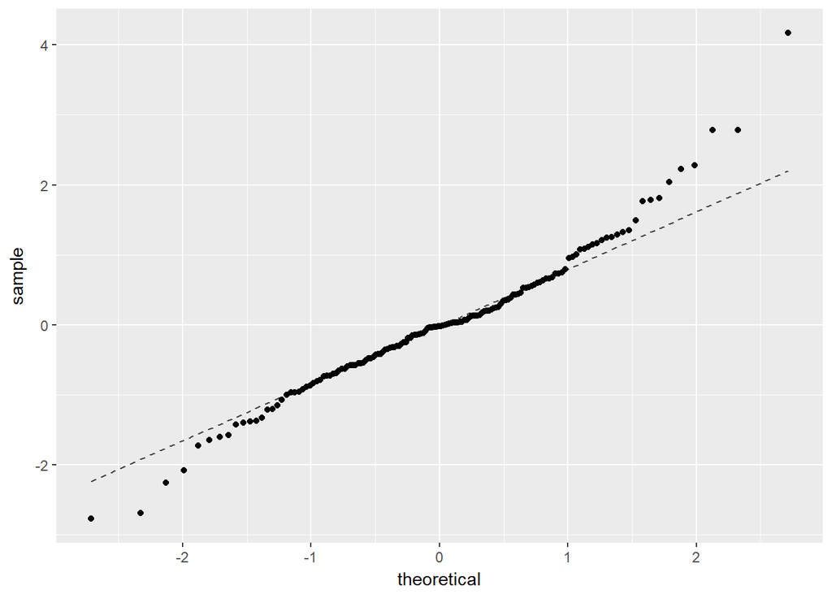

```r
gf_qq(~ std_res, data=rawDummy, distribution=qnorm) %>%
  gf_qqline(distribution=qnorm)
```

This QQ-plot tests the model assumption that the errors are approximately normally distributed. The data fits the straight (normal) line relatively well, suggesting that a normal distribution isn’t a bad approximation. Also, this graph seems to indicate one or two outliers which would contradict the assumption that all the observations have equal influence.

#### e.) The problems discovered in part (d) can sometimes be alleviated by changing the response from y to log(y). Create a new response variable: log(y). Fit the same model as in part (c), except using the new response variable: log(y). Note: Log base 10 of the expenditures is perhaps easier to interpret than natural log.

We change the response from y to log(y) and fit the same model as before:

```r
raw_logfit <- lm(log(y, base = 10) ~ x1 + x2 + x3 + region2 + region3 + region4 + year + year*x1 + year*x2 + year*x3, data = rawDummy)
tidy(raw_logfit)
```

```
##           term      estimate    std.error   statistic      p.value
## 1  (Intercept)  1.560530e+00 9.986319e-02 15.62668225 2.078498e-32
## 2           x1  2.042802e-04 2.303646e-05  8.86769053 3.255906e-15
## 3           x2  7.361055e-05 1.744044e-04  0.42206817 6.736273e-01
## 4           x3 -1.656538e-04 6.596496e-05 -2.51123953 1.317552e-02
## 5      region2  2.493975e-02 1.506686e-02  1.65527185 1.001255e-01
## 6      region3  8.085911e-04 1.603168e-02  0.05043707 9.598465e-01
## 7      region4  8.832339e-02 1.590520e-02  5.55311238 1.378712e-07
## 8         year  7.248962e-03 1.230775e-02  0.58897541 5.568337e-01
## 9      x1:year -7.166606e-06 1.446879e-06 -4.95314682 2.086481e-06
## 10     x2:year  6.556682e-05 2.719311e-05  2.41115563 1.720834e-02
## 11     x3:year  6.016874e-06 5.870579e-06  1.02492002 3.071813e-01
```

#### f.) Check basic model assumptions (linear relationship to Y, error variance, normality, influence, etc.)

To check linear relationship to Y, we use a standardized residuals vs. fitted values plot, and a scatterplot matrix with the predictor variables.

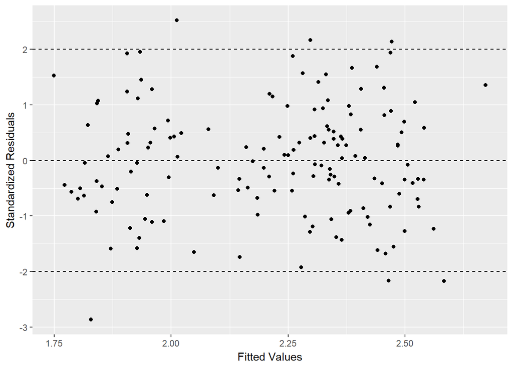

```r
rawDummy <- rawDummy %>%
  mutate(std_res = rstandard(raw_logfit), fitted_values = fitted(raw_logfit))

gf_point(std_res ~ fitted_values, data=rawDummy) %>%
  gf_labs(x = "Fitted Values", y = "Standardized Residuals") %>%
  gf_hline(yintercept = c(-2,0,2), linetype=2)
```

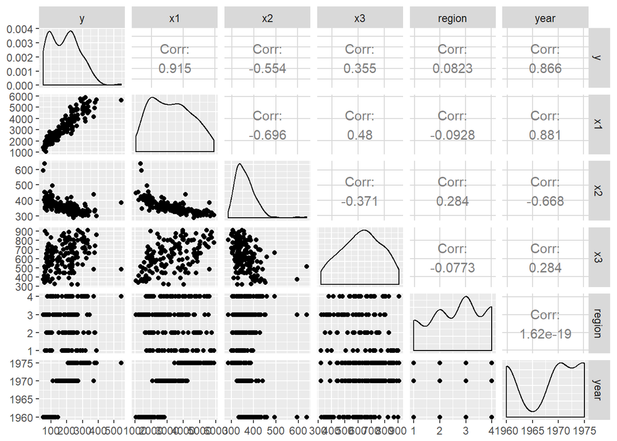

```r
ggpairs(rawData[, 2:7])
```

From the graph of the standardized residuals vs. fitted values we can see that the linear model is a reasonable assumption. Also, from the majority of the predictor variables it seems that there is a linear relationship to the response variable, so the linear model form assumption holds in this case.

We use a standardized residuals vs. fitted values plot to check the error variance assumption:

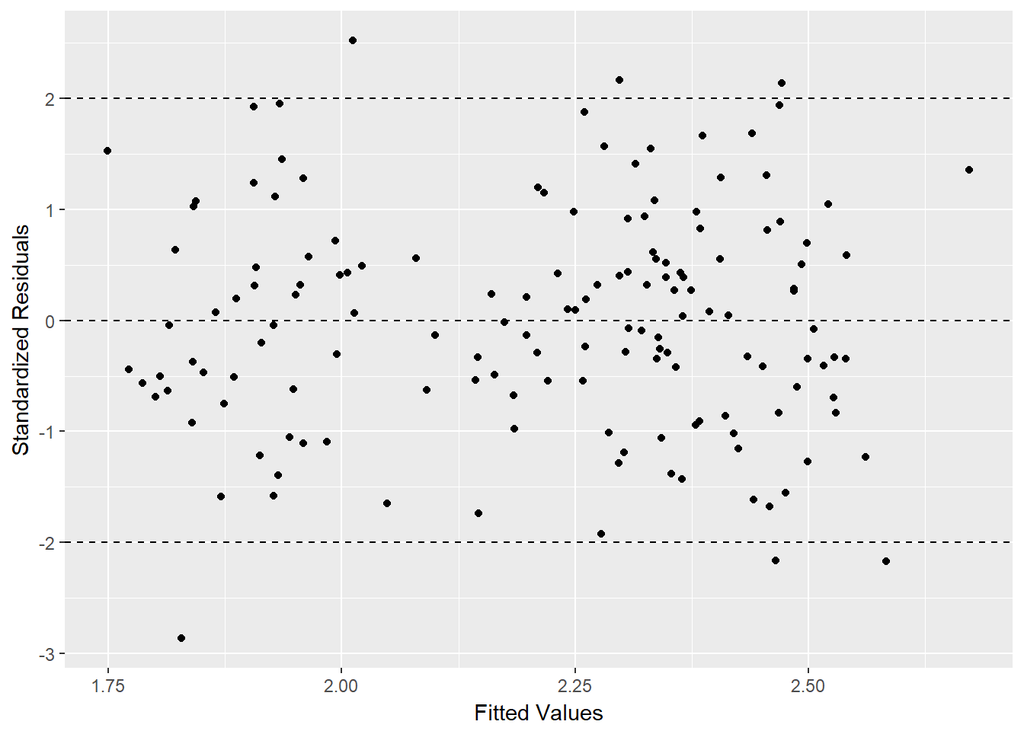

```r
rawDummy <- rawDummy %>%
  mutate(std_res = rstandard(raw_logfit), fitted_values = fitted(raw_logfit))

gf_point(std_res ~ fitted_values, data=rawDummy) %>%
  gf_labs(x = "Fitted Values", y = "Standardized Residuals") %>%
  gf_hline(yintercept = c(-2,0,2), linetype=2)
```

The constant variance assumption seems to hold here as the spread around the horizontal line at 0 is constant over all the fitted values.

We use a QQ-Plot as before to check for normality of the errors:

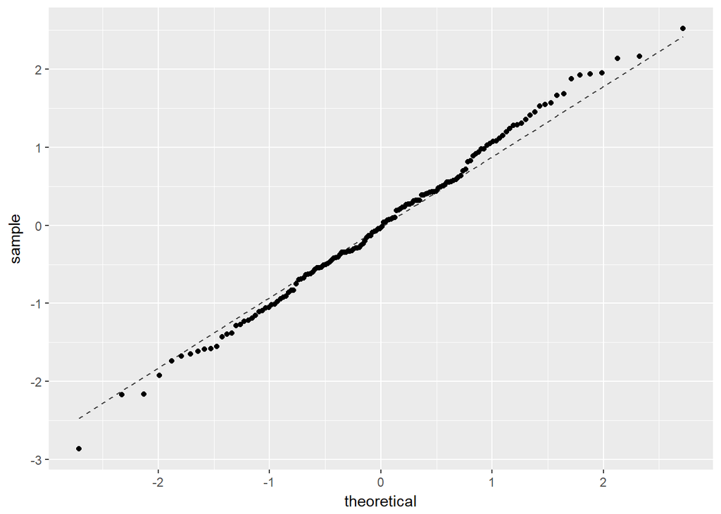

```r
gf_qq(~ std_res, data=rawDummy, distribution=qnorm) %>%
  gf_qqline(distribution=qnorm)
```

The QQ-Plot shows that the errors fit the normal distribution well, as the data lies mostly along the straight (normal) line.

To test whether the observations have equal influence, we use a graph of Cook’s distance:

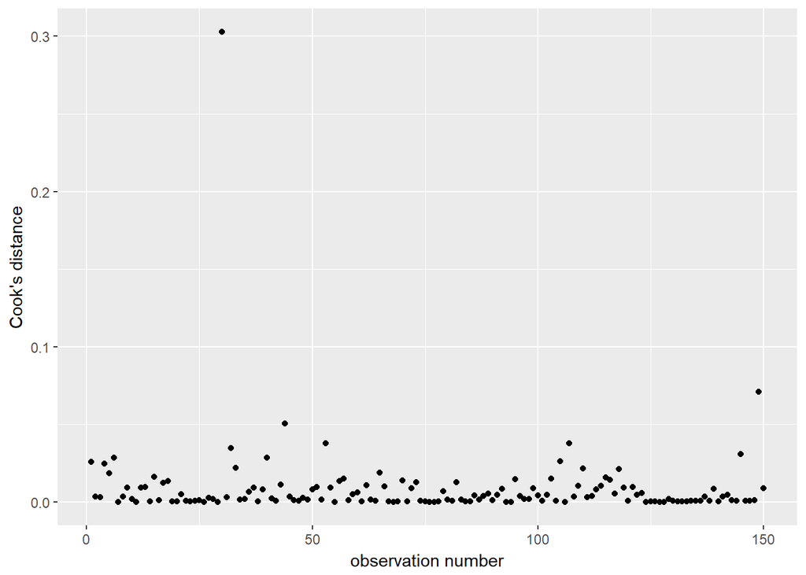

```r
rawDummy <- mutate(rawDummy, C = cooks.distance(raw_logfit))
gf_point(C ~ c(1:150), data=rawDummy) %>%
  gf_labs(x = "observation number", y = "Cook's distance") %>%
  gf_hline(yintercept = 1, linetype=2)
```

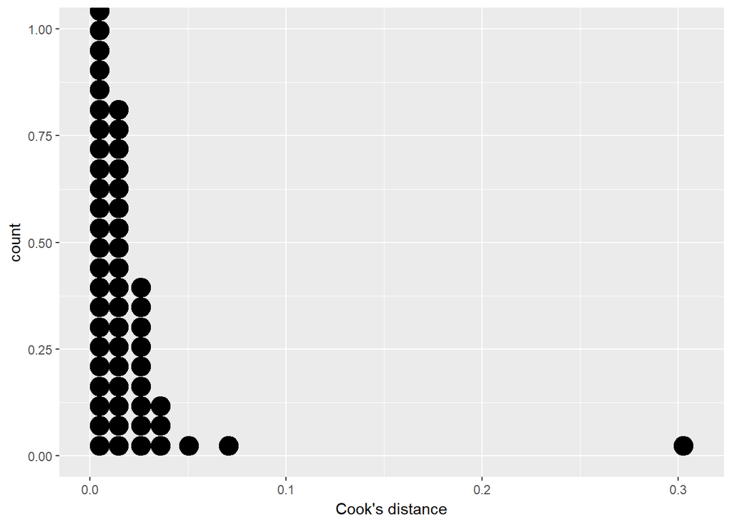

```r
gf_dotplot(~ C, data=rawDummy) %>%
  gf_labs(x = "Cook's distance")
```

It seems that there is an outlier which would need to be investigated, as this shows one observation having a much stronger influence than the rest, which contradicts the model assumption of equal influence.

#### g.) Test the overall effects of X1, X2, X3 on Y . Specify the hypothesis to be tested, the test used and your conclusions at the 5% significance level.

To test the overall effects of x1, x2, x3 on Y, we perform a regression where the model includes the response (Y) and only x1, x2, and x3 as predictor variables.

```r
raw_fit_x1x2x3 <- lm(y ~ x1 + x2 + x3, data = rawDummy)
summary(raw_fit_x1x2x3)
```

```
##
## Call:
## lm(formula = y ~ x1 + x2 + x3, data = rawDummy)
##
## Residuals:
##     Min      1Q  Median      3Q     Max
## -87.890 -18.531  -3.049  16.798 153.381
##
## Coefficients:
##               Estimate Std. Error t value Pr(>|t|)
## (Intercept) -1.419e+02  4.059e+01  -3.496 0.000627 ***
## x1           8.021e-02  3.448e-03  23.261  < 2e-16 ***
## x2           2.979e-01  8.431e-02   3.533 0.000550 ***
## x3          -6.340e-02  2.209e-02  -2.870 0.004716 **
## ---
## Signif. codes:  0 '***' 0.001 '**' 0.01 '*' 0.05 '.' 0.1 ' ' 1
##
## Residual standard error: 35.67 on 146 degrees of freedom
## Multiple R-squared:  0.8582, Adjusted R-squared:  0.8553
## F-statistic: 294.7 on 3 and 146 DF,  p-value: < 2.2e-16
```

To check whether the model assumptions are met in this case, we use the standard diagnostic plots:

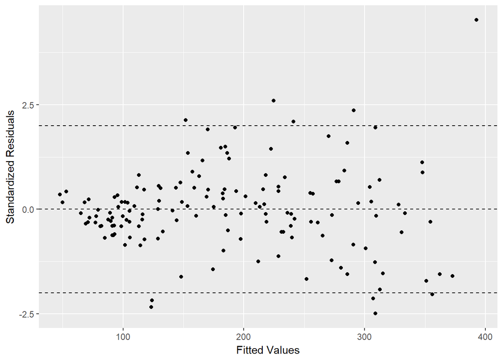

```r
rawDummy <- rawDummy %>%
  mutate(std_res = rstandard(raw_fit_x1x2x3), fitted_values = fitted(raw_fit_x1x2x3))

gf_point(std_res ~ fitted_values, data=rawDummy) %>%
  gf_labs(x = "Fitted Values", y = "Standardized Residuals") %>%
  gf_hline(yintercept = c(-2,0,2), linetype=2)
```

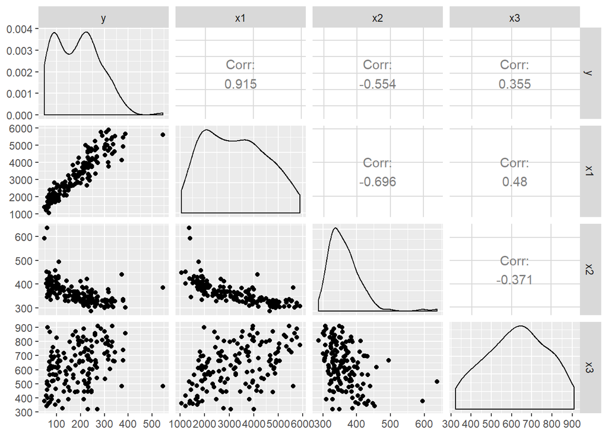

```r
ggpairs(rawData[, 2:5])
```

From the graph of the standardized residuals vs. fitted values we can see that the linear model is a reasonable assumption. Also, from the majority of the predictor variables it seems that there is a linear relationship to the response variable, so the linear model form assumption holds in this case.

We use a standardized residuals vs. fitted values plot to check the error variance assumption:

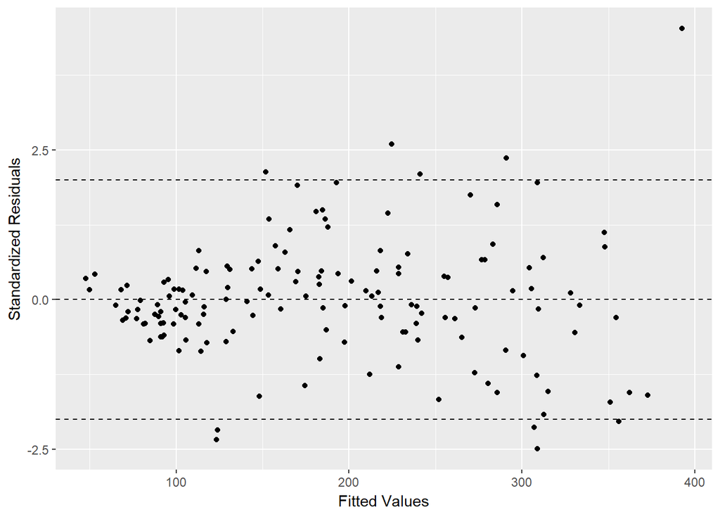

```r
rawDummy <- rawDummy %>%
  mutate(std_res = rstandard(raw_fit_x1x2x3), fitted_values = fitted(raw_fit_x1x2x3))

gf_point(std_res ~ fitted_values, data=rawDummy) %>%
  gf_labs(x = "Fitted Values", y = "Standardized Residuals") %>%
  gf_hline(yintercept = c(-2,0,2), linetype=2)
```

It seems that the constant variance assumption does not hold here as the spread around the horizontal line at 0 seems to increase as the fitted values increase, but it is possible that this non-constant variance could be corrected by including the region variable.

We use a QQ-Plot as before to check for normality of the errors:

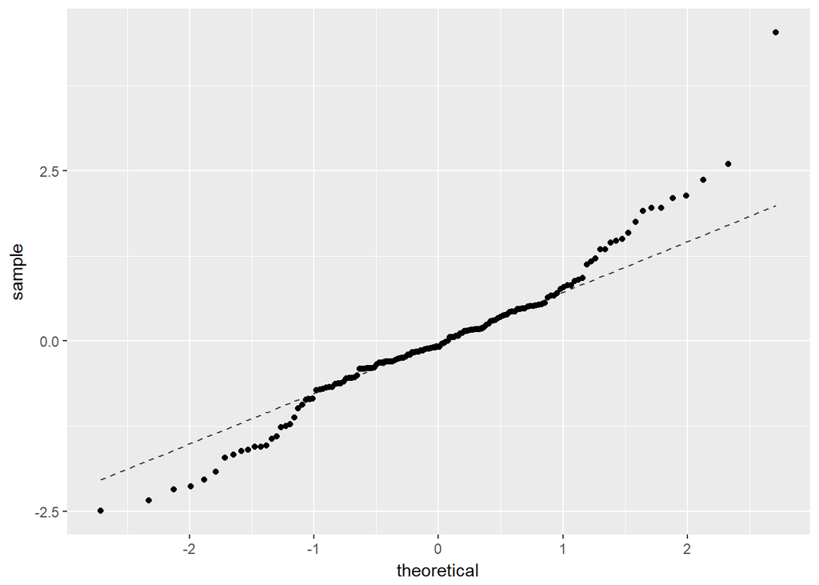

```r
gf_qq(~ std_res, data=rawDummy, distribution=qnorm) %>%
  gf_qqline(distribution=qnorm)
```

To test whether the observations have equal influence, we use a graph of Cook’s distance:

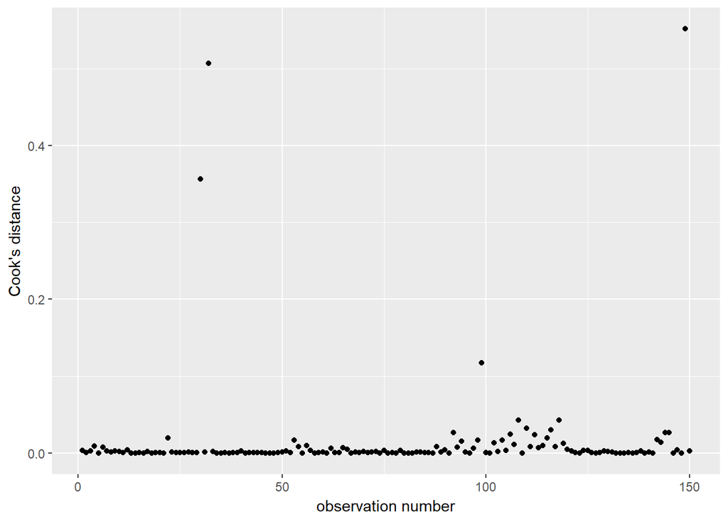

```r
rawDummy <- mutate(rawDummy, C = cooks.distance(raw_fit_x1x2x3))
gf_point(C ~ c(1:150), data=rawDummy) %>%
  gf_labs(x = "observation number", y = "Cook's distance") %>%
  gf_hline(yintercept = 1, linetype=2)
```

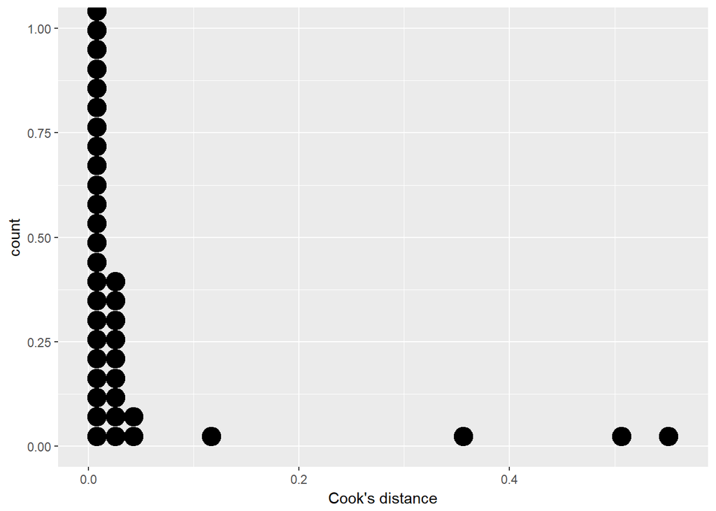

```r
gf_dotplot(~ C, data=rawDummy) %>%
  gf_labs(x = "Cook's distance")
```

Here we have a few outliers that would need to be examined in order to fully validate the assumption that the observations have equal influence.

In order to test whether there is an overall effect from X1, X2, X3 on Y, we use an F-Test and we test the hypotheses: $\begin{aligned}H_0: \beta_1 = \beta_2 = \beta_3 = 0 \ vs. \ H_A:\beta_i \neq 0\end{aligned}$ (for i = 1, 2, 3).

We use the anova function in R to compare the full model with the model under the null hypothesis where all the coefficients for the slops equal zero:

```r
raw_fit_x1x2x3_FM <- lm(y ~ x1 + x2 + x3, data = rawDummy)
raw_fit_x1x2x3_RM <- lm(y ~ 1, data = rawDummy)
anova(raw_fit_x1x2x3_RM, raw_fit_x1x2x3_FM)
```

```
## Analysis of Variance Table
##
## Model 1: y ~ 1
## Model 2: y ~ x1 + x2 + x3
##   Res.Df     RSS Df Sum of Sq      F    Pr(>F)
## 1    149 1310497
## 2    146  185764  3   1124732 294.66 < 2.2e-16 ***
## ---
## Signif. codes:  0 '***' 0.001 '**' 0.01 '*' 0.05 '.' 0.1 ' ' 1
```

From the F-test, the p-value is very small so we are can reject the null hypothesis that all the slope coefficients are zero. We conclude that there is a statistically significant overall effect from x1, x2, x3.

#### h.) Test whether the effects of X1, X2, X3 remain unchanged over time. Specify the hypothesis to be tested, the test used and your conclusions at the 5% significance level.

To test whether the effects of X1, X2, X3 remain unchanged over time we use the model with Y as the response and x1, x2, x3, year, and the interaction terms as the predictors. We test the hypotheis that the the effects of x1, x2, x4 remain unchanged over time by testing the null hypothesis that all the coefficients of the interaction terms are zero. We perform an F-test using a full vs. reduced model as before.

```r
raw_fit_year_interact_FM <- lm(y ~ x1 + x2 + x3 + region2 + region3 + region4 + year + (year*x1) + (year*x2) + (year*x3), data = rawDummy)
raw_fit_year_interact_RM <- lm(y ~ x1 + x2 + x3 + region2 + region3 + region4 + year, data = rawDummy)
anova(raw_fit_year_interact_RM, raw_fit_year_interact_FM)
```

```
## Analysis of Variance Table
##
## Model 1: y ~ x1 + x2 + x3 + region2 + region3 + region4 + year
## Model 2: y ~ x1 + x2 + x3 + region2 + region3 + region4 + year + (year *
##     x1) + (year * x2) + (year * x3)
##   Res.Df    RSS Df Sum of Sq      F   Pr(>F)
## 1    142 135344
## 2    139 109165  3     26179 11.111 1.39e-06 ***
## ---
## Signif. codes:  0 '***' 0.001 '**' 0.01 '*' 0.05 '.' 0.1 ' ' 1
```

From the F-test, the p-value is very small so we can reject the null hypothesis that all the slope coefficients are zero. We conclude that there is a statistically significant change over time in the effects of X1, X2, X3 on Y.

#### i.) Based on findings in (h) decide whether separate regressions by year interval need to be reported. Report coefficients for X variables separately by year (i.e., fit a separate model for each year).

Based on the test in (h), which showed that the effects of x1, x2, x3 change over time, separate regressions by year interval do need to be reported. In order to separate the regression models based on the year, we create indicator variables for the different years:

```r
rawDummy <- dummy.data.frame(rawDummy, names=c("year"))
```

```r
raw_fit_year_1 <- lm(y ~ x1 + x2 + x3 + region2 + region3 + region4 + year0, data = rawDummy)
raw_fit_year_2 <- lm(y ~ x1 + x2 + x3 + region2 + region3 + region4 + year10, data = rawDummy)
raw_fit_year_3 <- lm(y ~ x1 + x2 + x3 + region2 + region3 + region4 + year15, data = rawDummy)
tidy(raw_fit_year_1)
```

```
##          term     estimate    std.error  statistic      p.value
## 1 (Intercept) -61.36733394 36.884442973 -1.6637728 9.836319e-02
## 2          x1   0.06544334  0.003799392 17.2246899 1.342160e-36
## 3          x2   0.22921926  0.077816613  2.9456341 3.767643e-03
## 4          x3  -0.06920551  0.019764373 -3.5015284 6.186648e-04
## 5     region2   4.24915437  7.947348296  0.5346632 5.937190e-01
## 6     region3   0.97086874  8.020422485  0.1210496 9.038229e-01
## 7     region4  35.80842966  8.125559494  4.4068879 2.053289e-05
## 8       year0 -43.24996482  8.698740436 -4.9719802 1.883003e-06
```

```r
tidy(raw_fit_year_2)
```

```
##          term      estimate    std.error  statistic      p.value
## 1 (Intercept) -103.83733541 37.503570445 -2.7687320 6.379039e-03
## 2          x1    0.07913649  0.003118795 25.3740622 1.292042e-54
## 3          x2    0.19152860  0.078432114  2.4419665 1.583659e-02
## 4          x3   -0.09254404  0.020500590 -4.5142136 1.323654e-05
## 5     region2    5.67555849  8.099125622  0.7007619 4.845983e-01
## 6     region3    8.97511669  7.944446974  1.1297346 2.604928e-01
## 7     region4   39.47692363  8.235688181  4.7933971 4.088707e-06
## 8      year10   23.42988410  5.530514062  4.2364749 4.062381e-05
```

```r
tidy(raw_fit_year_3)
```

```
##          term     estimate    std.error  statistic      p.value
## 1 (Intercept) -94.15778061 39.093957490 -2.4084996 1.730082e-02
## 2          x1   0.08527056  0.005029962 16.9525249 6.178259e-36
## 3          x2   0.15078150  0.081406788  1.8521981 6.607375e-02
## 4          x3  -0.09602780  0.022981199 -4.1785375 5.101499e-05
## 5     region2   7.28239694  8.450777116  0.8617429 3.902819e-01
## 6     region3  14.30060933  8.436108954  1.6951665 9.223555e-02
## 7     region4  42.24687535  8.615357321  4.9036707 2.538567e-06
## 8      year15 -23.14893359 10.771276106 -2.1491357 3.331878e-02
```

## 2.) Modified from Exercises 5.7

### Three types of fertilizer are to be tested to see which one yields more corn crop. Forty similar plots of land were available for testing purposes. The 40 plots are divided at random into four groups, 10 plots in each group. Fertilizer 1 was applied to each of the 10 corn plots in Group 1. Similarly, Fertilizers 2 and 3 were applied to the plots in Groups 2 and 3, respectively. The corn plants in Group 4 were not given any fertilizer; it will serve as the control group. Table 5.17 gives the corn yield yij for each of the 40 plots.

```r
fertilizerData <- read.delim("http://statistics.uchicago.edu/~collins/data/RABE5/P158.txt")
head(fertilizerData)
```

```
##   Yield Fertilizer
## 1    31          1
## 2    34          1
## 3    34          1
## 4    34          1
## 5    43          1
## 6    35          1
```

#### a.) Create three indicator variables, F1, F2, F3, one for each of the three fertilizer groups (to compare against control)

We create indicator variables using the “dummies” package in R:

```r
fertilizerDummy <- dummy.data.frame(fertilizerData, names=c("Fertilizer"))
fertilizerDummy <- mutate(fertilizerDummy, Fertilizer = fertilizerData$Fertilizer)
colnames(fertilizerDummy) <- c("Yield", "F1", "F2", "F3", "Control", "Fertilizer")
kable(head(fertilizerDummy, 10))
```

| Yield | F1 | F2 | F3 | Control | Fertilizer |
| --- | --- | --- | --- | --- | --- |
| 31 | 1 | 0 | 0 | 0 | 1 |
| 34 | 1 | 0 | 0 | 0 | 1 |
| 34 | 1 | 0 | 0 | 0 | 1 |
| 34 | 1 | 0 | 0 | 0 | 1 |
| 43 | 1 | 0 | 0 | 0 | 1 |
| 35 | 1 | 0 | 0 | 0 | 1 |
| 38 | 1 | 0 | 0 | 0 | 1 |
| 36 | 1 | 0 | 0 | 0 | 1 |
| 36 | 1 | 0 | 0 | 0 | 1 |
| 45 | 1 | 0 | 0 | 0 | 1 |

#### b.) Fit the model yij = µ0 + µ1Fi1 + µ2Fi2 + µ3Fi3 + eij .

We fit the following linear model in R:

```r
fertilizerfit = lm(Yield~F1+F2+F3, data = fertilizerDummy)
tidy(fertilizerfit)
```

```
##          term estimate std.error   statistic      p.value
## 1 (Intercept)     29.8  1.532790 19.44167478 1.115032e-20
## 2          F1      6.8  2.167692  3.13697693 3.395176e-03
## 3          F2      0.1  2.167692  0.04613201 9.634600e-01
## 4          F3      5.1  2.167692  2.35273270 2.422045e-02
```

#### c.) Test the hypothesis that none of the three types of fertilizer has an effect on corn crops. Specify the hypothesis to be tested, the test used, and your conclusions at the 5% significance level.

The null hypothesis is that all the slope coefficients equal zero, and the alternative hypothesis is that at least one of the fertilizer has an effect on corn crops: $\begin{aligned}H_0: \mu_1 = \mu_2 = \mu_3 = 0 \ vs. \ H_A:\mu_i \neq 0\end{aligned}$ (for i = 1, 2, 3).

We use an F-Test in R:

```r
glance(fertilizerfit)[-c(7:10)]
```

```
##   r.squared adj.r.squared    sigma statistic     p.value df df.residual
## 1 0.3000662     0.2417384 4.847107  5.144479 0.004604797  4          36
```

The value of the F-statistic is 5.14 and we have a p-value of 0.0046 which is less than our significance level of 0.05. The conclusion is that we can reject the null hypothesis and say that at least one of the fertilizer groups has a statistically significant effect on corn crops compared to the control group.

#### d.) Test the hypothesis that the three types of fertilizer have equal effects on corn crop. Specify the hypothesis to be tested, the test used and your conclusions at the 5% significance level.

The null hypothesis is that all the slope coefficients are equal, versus the alternative hypothesis that at least two of them are not equal.  
$\begin{aligned}H_0: \mu_1 = \mu_2 = \mu_3 \ vs. \ H_A:\mu_i \neq \mu_j\end{aligned}$ (for i,j = 1, 2, 3).

We use an F-Test with a reduced model vs. the full model:

```r
fertilizerfit_FM <- fertilizerfit
fertilizerfit_RM <- lm(Yield ~ I(F1 + F2 + F3), data = fertilizerDummy)
anova(fertilizerfit_RM, fertilizerfit_FM)
```

```
## Analysis of Variance Table
##
## Model 1: Yield ~ I(F1 + F2 + F3)
## Model 2: Yield ~ F1 + F2 + F3
##   Res.Df    RSS Df Sum of Sq      F  Pr(>F)
## 1     38 1088.4
## 2     36  845.8  2     242.6 5.1629 0.01068 *
## ---
## Signif. codes:  0 '***' 0.001 '**' 0.01 '*' 0.05 '.' 0.1 ' ' 1
```

The value of the F-statistic is 5.16 and the p-value is 0.01 which is less than 0.05. At the 5% significance level, we would conclude that there is some difference between the effects of the fertilizer groups.

#### e.) Irrespective of the results in (d), test whether there is a common effect of fertilizer, call it µF , relative to control.

We assume that the effects of the different groups are equal, and this effect if $\mu_F$. We use the same reduced model that we had in part (d) and we use the lm function in R to use a t-test for the hypothesis that this coefficient is statistically different from zero: $\begin{aligned}H_0: \mu_F = 0 \ vs. \ H_A:\mu_F \neq 0\end{aligned}$

```r
fertilizerfit_RM <- lm(Yield ~ I(F1 + F2 + F3), data = fertilizerDummy)
tidy(fertilizerfit_RM)
```

```
##              term estimate std.error statistic      p.value
## 1     (Intercept)     29.8  1.692398  17.60815 7.206804e-20
## 2 I(F1 + F2 + F3)      4.0  1.954213   2.04686 4.763348e-02
```

The t-statistic is 2.047 and the p-value is 0.0476 for $\mu_F = 0$. Testing at the 5% significance level, we reject the null hypothesis because the p-value = 0.0476 is less than 0.05. Assuming that there is a common effect of fertilizer, we reject the null hypothesis that it has no effect and we conclude that there is some non-zero common effect.

## 4.) Exercise 5.6 PARTS a-f

### The price of a car is thought to depend on the horsepower of the engine and the country where the car is made. The variable Country has four categories: USA, Japan, Germany, and Others. To include the variable Country in a regression equation, three indicator variables are created, one for USA, another for Japan, and the third for Germany. In addition, there are three interaction variables between horsepower and each of the three Country categories. Some regression outputs when fitting three models to the data is shown in Table 5.16 (for those of you who do not have the new version of the textbook, Table 5.16 is on the last page of this homework). The usual regression assumptions hold.

```r
carData <- read.delim("http://statistics.uchicago.edu/~collins/data/RABE5/P155b.txt")
head(carData)
```

```
##             Car Country      Y Horsepower
## 1 Acura Integra   Japan 12.100        130
## 2  Eagle Summit     USA  6.949         92
## 3   Ford Escort     USA  7.976         88
## 4  Ford Festiva   Other  6.620         63
## 5     Geo Metro   Japan  6.795         55
## 6     Geo Prizm     USA  9.680        102
```

#### a.) Compute the correlation coefficient between the price and the horsepower.

We use the standard correlation function in R:

```r
carData$Horsepower <- as.numeric(carData$Horsepower)
cor(carData$Horsepower, carData$Y)
```

```
## [1] 0.8611619
```

We create the indicator variables and use the Model 3 from the textbook, and fit the corresponding regression model:

```r
carDummy <- dummy.data.frame(carData, names=c("Country"))
carDummy <- mutate(carDummy, Country = carData$Country)
carFit <- lm(Y ~ Horsepower + CountryGermany + CountryUSA + CountryJapan + (Horsepower*CountryGermany) + (Horsepower*CountryUSA) + (Horsepower*CountryJapan), data = carDummy)
tidy(carFit)
```

```
##                        term     estimate  std.error  statistic
## 1               (Intercept) -10.88176083 4.21576463 -2.5812069
## 2                Horsepower   0.23732073 0.03819472  6.2134431
## 3            CountryGermany  11.77444778 9.23469248  1.2750233
## 4                CountryUSA   2.07573611 4.91644477  0.4222027
## 5              CountryJapan   4.75521321 4.68515488  1.0149533
## 6 Horsepower:CountryGermany  -0.09507366 0.06639974 -1.4318379
## 7     Horsepower:CountryUSA  -0.05218890 0.04226560 -1.2347844
## 8   Horsepower:CountryJapan  -0.07656473 0.04064078 -1.8839387
##        p.value
## 1 1.162560e-02
## 2 2.045506e-08
## 3 2.059018e-01
## 4 6.739820e-01
## 5 3.131135e-01
## 6 1.559910e-01
## 7 2.204373e-01
## 8 6.311744e-02
```

## 5.) Box-Cox Analysis

### In class, we saw that a natural log transform of price was sufficient for using a linear model predicting price with age of Port wine.

```r
wineData <- read.delim("http://statistics.uchicago.edu/~collins/data/STAT224other/wine.txt")
head(wineData)
```

```
##   vintage_yr price
## 1       1890 50.00
## 2       1900 35.00
## 3       1920 25.00
## 4       1931 11.98
## 5       1934 15.00
## 6       1935 13.00
```

#### a.) Run the Box-Cox analysis for transformation of the response variable. Obtain the suggested ?? parameter. Depending on which section of the course you are taking, the boxcox method was demonstrated in Stata or R during lecture. (In R, use the boxcox function in the MASS package. The default plot will show you the range of lambda values against the log likelihood.)

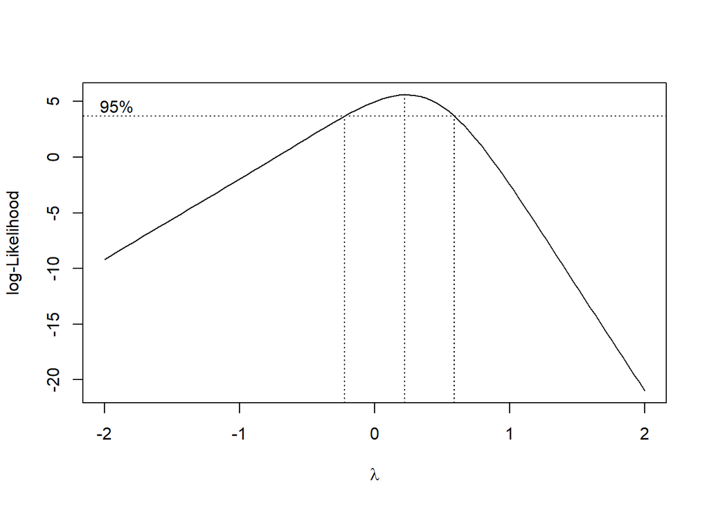

```r
boxcox(lm(price ~ vintage_yr, data = wineData))
```

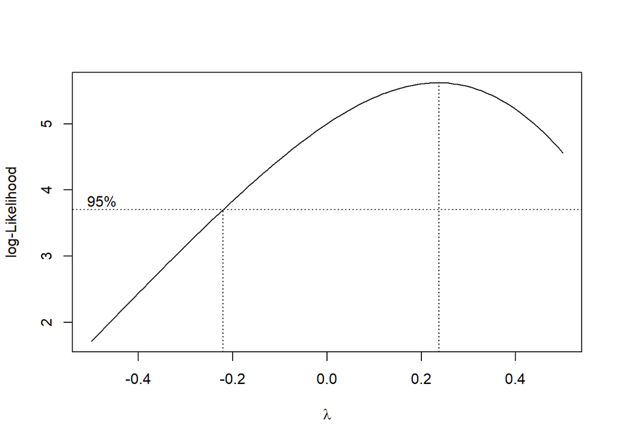

```r
boxcox(lm(price ~ vintage_yr, data = wineData), lambda = seq(-0.5, 0.5, 0.1))
```

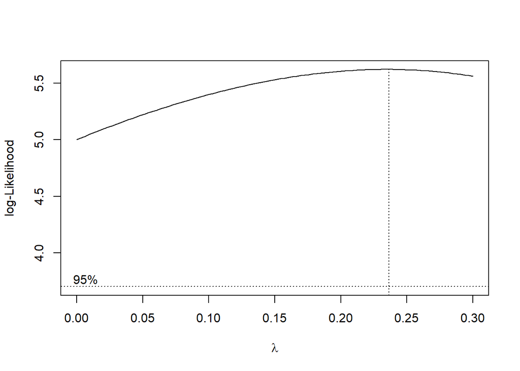

```r
boxcox(lm(price ~ vintage_yr, data = wineData), lambda = seq(0, 0.3, 0.1))
```

We have $\lambda = 0$ inside the interval so the transformation log(Y), or log(Price), is also suggested from the box-cox analysis. The log-likelihood is maximized when lambda = 0.24, which suggests the power transformation with lambda = 0.24.

#### b.) Transform Y (price) according the Box-Cox suggested transformation and perform the regression. Compare to the results for using log(price) as the response variable.

First we use age = 1972 - vintage year just like in the class example. We then transform price with the Box-Cox suggested power transformation: $\frac{y_i^\lambda - 1}{\lambda}$ with lambda = 0.24. We then perform the regression the same way as before and also perform the regression using log(Y).

```r
wineData <- wineData %>%
  mutate(age = 1972 - vintage_yr)
boxcoxfit <- lm((price^(0.24)-1)/(.24) ~ age, data = wineData)
logfit <- lm(log(price) ~ age, data = wineData)
summary(boxcoxfit)
```

```
##
## Call:
## lm(formula = (price^(0.24) - 1)/(0.24) ~ age, data = wineData)
##
## Residuals:
##      Min       1Q   Median       3Q      Max
## -0.59381 -0.24876  0.07625  0.22190  0.43757
##
## Coefficients:
##             Estimate Std. Error t value Pr(>|t|)
## (Intercept) 0.912243   0.193949   4.704 0.000511 ***
## age         0.067410   0.004707  14.321 6.59e-09 ***
## ---
## Signif. codes:  0 '***' 0.001 '**' 0.01 '*' 0.05 '.' 0.1 ' ' 1
##
## Residual standard error: 0.3438 on 12 degrees of freedom
## Multiple R-squared:  0.9447, Adjusted R-squared:  0.9401
## F-statistic: 205.1 on 1 and 12 DF,  p-value: 6.593e-09
```

```r
summary(logfit)
```

```
##
## Call:
## lm(formula = log(price) ~ age, data = wineData)
##
## Residuals:
##      Min       1Q   Median       3Q      Max
## -0.32405 -0.08294  0.04127  0.12533  0.27310
##
## Coefficients:
##             Estimate Std. Error t value Pr(>|t|)
## (Intercept) 1.143891   0.113931   10.04 3.43e-07 ***
## age         0.034652   0.002765   12.53 2.98e-08 ***
## ---
## Signif. codes:  0 '***' 0.001 '**' 0.01 '*' 0.05 '.' 0.1 ' ' 1
##
## Residual standard error: 0.202 on 12 degrees of freedom
## Multiple R-squared:  0.929,  Adjusted R-squared:  0.9231
## F-statistic:   157 on 1 and 12 DF,  p-value: 2.978e-08
```

The R-squared for the model with the box-cox suggested transformation is slightly higher than the R-squared for the model with the log transformation. Both models show statistically significant effects for age and both models have very low p-values.

To compare the models further, we plot the standardized residuals vs. the fitted values for both of the models.

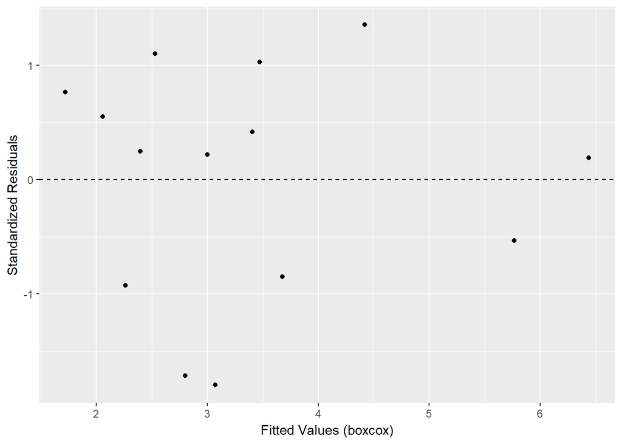

```r
wineData <- wineData %>%
  mutate(std_res = rstandard(boxcoxfit), fitted_values = fitted(boxcoxfit))

gf_point(std_res ~ fitted_values, data=wineData) %>%
  gf_labs(x = "Fitted Values (boxcox)", y = "Standardized Residuals") %>%
  gf_hline(yintercept = c(-2,0,2), linetype=2)
```

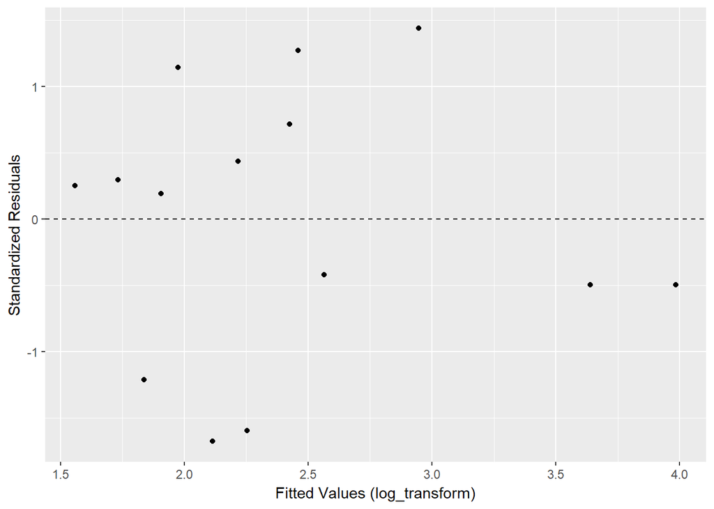

```r
wineData <- wineData %>%
  mutate(std_res = rstandard(logfit), fitted_values = fitted(logfit))

gf_point(std_res ~ fitted_values, data=wineData) %>%
  gf_labs(x = "Fitted Values (log_transform)", y = "Standardized Residuals") %>%
  gf_hline(yintercept = c(-2,0,2), linetype=2)
```

This doesn’t really show a significant difference between the log transform model and the boxcox transform model, however it seems that both models are a pretty good fit for the data.

## 6.) Diamond Data

### Continuing with the diamond data from previous homework. Although we saw some issues with model assumptions (which may be a function of the small sample at lower carat weight), for now ignore and do the following.

```r
diamondData <- read.csv("http://statistics.uchicago.edu/~collins/data/STAT224other/diamond_set1.txt")
head(diamondData)
```

```
##   carat        x1 x2   x3 price     yhat
## 1  0.31 Excellent  D  VS1  1106 672.8148
## 2  0.31 Excellent  D VVS1  1144 672.8148
## 3  0.31      Good  F VVS2  1166 672.8148
## 4  0.31 Excellent  D VVS1  1173 672.8148
## 5  0.32      Fair  F  VS1  1114 745.3206
## 6  0.33 Excellent  F VVS2  1084 817.8266
```

#### a.) Test for a carat by color (coded as ordinal numeric) interaction effect, and decide if this term is needed in the model.

First we code color as an ordinal numeric variable:

```r
conversion = c("D"=6, "E"=5, "F"=4, "G"=3, "H"=2, "I"=1, "J"=0)
diamondData$numcolor <- conversion[diamondData$x2]
```

Now we fit a regression model with the interaction term:

```r
diamondFit <- lm(price ~ carat + numcolor + (carat*numcolor), data = diamondData)
summary(diamondFit)
```

```
##
## Call:
## lm(formula = price ~ carat + numcolor + (carat * numcolor), data = diamondData)
##
## Residuals:
##      Min       1Q   Median       3Q      Max
## -1991.06  -519.07   -15.63   578.25  1322.23
##
## Coefficients:
##                 Estimate Std. Error t value Pr(>|t|)
## (Intercept)    -3163.101    892.160  -3.545  0.00106 **
## carat           8121.762   1091.058   7.444 6.22e-09 ***
## numcolor         270.179    199.611   1.354  0.18389
## carat:numcolor     6.349    270.052   0.024  0.98137
## ---
## Signif. codes:  0 '***' 0.001 '**' 0.01 '*' 0.05 '.' 0.1 ' ' 1
##
## Residual standard error: 744.2 on 38 degrees of freedom
## Multiple R-squared:  0.871,  Adjusted R-squared:  0.8608
## F-statistic: 85.52 on 3 and 38 DF,  p-value: < 2.2e-16
```

From the t-test for the significance of the interaction term, we can see a very high p-value so we would not reject the null hypothesis that the interaction coefficient is zero. Therefore, we conclude that the interaction effect is not significant and so this interaction term wouldn’t be needed in the model.

#### b.) Variable X1 is diamond cut, with 4 rating categories. Create appropriate indicator variables and evaluate whether this categorical factor adds to price prediction in this dataset.

We create the indicator variables using the “dummies” package in R:

```r
diamondDummy <- dummy.data.frame(diamondData, names=c("x1"))
diamondDummy <- mutate(diamondDummy, x1 = diamondData$x1)
colnames(fertilizerDummy) <- c("Yield", "F1", "F2", "F3", "Control", "Fertilizer")
kable(head(fertilizerDummy, 10))
```

[output not shown]

Now we fit a model that has three of these indicator variables:

```r
diamondFit <- lm(price ~ x1Good + x1VeryGood + x1Excellent, data = diamondDummy)
summary(diamondFit)
```

```
##
## Call:
## lm(formula = price ~ x1Good + x1VeryGood + x1Excellent, data = diamondDummy)
##
## Residuals:
##     Min      1Q  Median      3Q     Max
## -2496.9 -1699.4  -236.2  1025.6  4316.8
##
## Coefficients:
##             Estimate Std. Error t value Pr(>|t|)
## (Intercept)   2564.5      955.4   2.684   0.0107 *
## x1Good       -1083.5     1197.7  -0.905   0.3713
## x1VeryGood    1222.4     1103.2   1.108   0.2748
## x1Excellent    505.7     1051.2   0.481   0.6332
## ---
## Signif. codes:  0 '***' 0.001 '**' 0.01 '*' 0.05 '.' 0.1 ' ' 1
##
## Residual standard error: 1911 on 38 degrees of freedom
## Multiple R-squared:  0.1494, Adjusted R-squared:  0.08227
## F-statistic: 2.225 on 3 and 38 DF,  p-value: 0.101
```

To test whether this categorical factor adds to the price prediction, we can use an F-Test to test the following hypotheses: $\begin{aligned}H_0: \beta_1 = \beta_2 = \beta_3 = 0 \ vs. \ H_A:\beta_i \neq 0\end{aligned}$ (for i = 1, 2, 3)

We use the anova function in R to compare the full model with the model under the null hypothesis where all the coefficients for the slops equal zero:

```r
diamondFit_FM <- lm(price ~ x1Good + x1VeryGood + x1Excellent, data = diamondDummy)
diamondFit_RM <- lm(price ~ 1, data = diamondDummy)
anova(diamondFit_RM, diamondFit_FM)
```

```
## Analysis of Variance Table
##
## Model 1: price ~ 1
## Model 2: price ~ x1Good + x1VeryGood + x1Excellent
##   Res.Df       RSS Df Sum of Sq      F Pr(>F)
## 1     41 163120339
## 2     38 138746672  3  24373666 2.2252  0.101
```

From the F-test, the p-value is 0.1 so we are not able to reject the null hypothesis that all the slope coefficients are zero. We conclude that the diamond cut, given as this categorical factor, is not significant and that the diamond cut does not add to the price prediction.